# MPDW 5

Alfikri Ihsan

2023-09-26

```r
library(ggplot2)
library(tsibble)
library(tseries)
library(MASS)
library(readxl)
```

1. Memasukkan data

```r
Data <- read_xlsx("F:/Semester 5/MPDW/Data Harga Cabai Merah.xlsx")
Dataa <- Data$Harga
```

2. plot time series

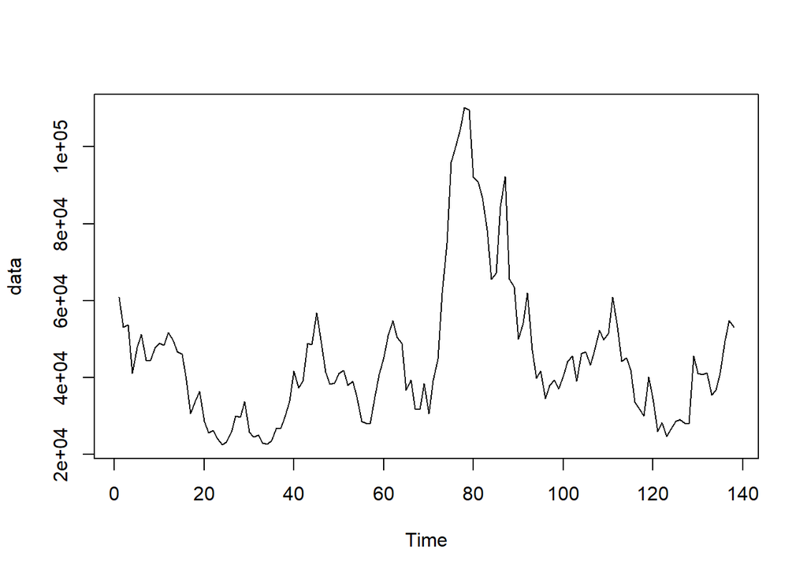

```r
data <- ts(Dataa)
plot.ts(data)
```

Data tidak stasioner dalam rataan dan ragam

3. plot ACF

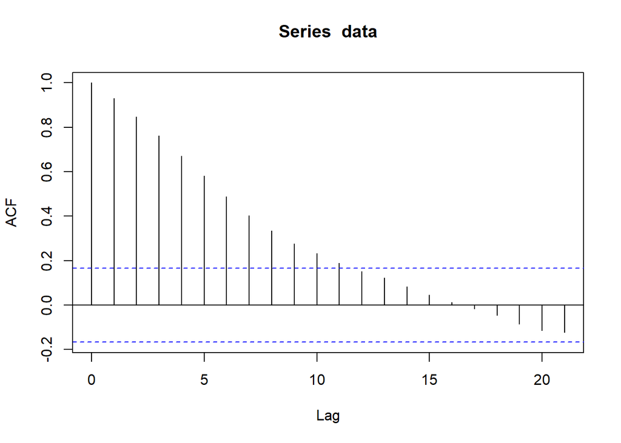

```r
acf(data)
```

Berdasarkan plot ACF terlihat bahwa data menurun secara Tails off slowly, sehingga dapat disimpulkan data tidak stasioner dalam rataan

4. uji ADF

```r
adf.test(data)
```

```
##
##  Augmented Dickey-Fuller Test
##
## data:  data
## Dickey-Fuller = -2.9437, Lag order = 5, p-value = 0.1838
## alternative hypothesis: stationary
```

$H_0$ : Data tidak stasioner dalam rataan

5. plot box cox

```r
index <- seq(1:138)
bc = boxcox(data~index, lambda = seq(-2,1,by=0.001))
```

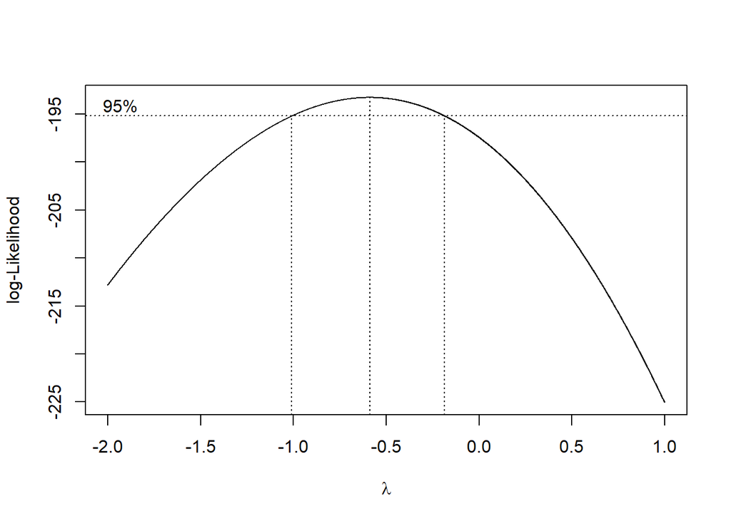

```r
#Nilai Rounded Lambda
lambda <- bc$x[which.max(bc$y)]
lambda
```

```
## [1] -0.589
```

```r
#SK
bc$x[bc$y > max(bc$y) - 1/2 * qchisq(.95,1)]
```

```
##   [1] -1.008 -1.007 -1.006 -1.005 -1.004 -1.003 -1.002 -1.001 -1.000 -0.999
##  [11] -0.998 -0.997 -0.996 -0.995 -0.994 -0.993 -0.992 -0.991 -0.990 -0.989
##  [21] -0.988 -0.987 -0.986 -0.985 -0.984 -0.983 -0.982 -0.981 -0.980 -0.979
##  [31] -0.978 -0.977 -0.976 -0.975 -0.974 -0.973 -0.972 -0.971 -0.970 -0.969
##  [41] -0.968 -0.967 -0.966 -0.965 -0.964 -0.963 -0.962 -0.961 -0.960 -0.959
##  [51] -0.958 -0.957 -0.956 -0.955 -0.954 -0.953 -0.952 -0.951 -0.950 -0.949
##  [61] -0.948 -0.947 -0.946 -0.945 -0.944 -0.943 -0.942 -0.941 -0.940 -0.939
##  [71] -0.938 -0.937 -0.936 -0.935 -0.934 -0.933 -0.932 -0.931 -0.930 -0.929
##  [81] -0.928 -0.927 -0.926 -0.925 -0.924 -0.923 -0.922 -0.921 -0.920 -0.919
##  [91] -0.918 -0.917 -0.916 -0.915 -0.914 -0.913 -0.912 -0.911 -0.910 -0.909
## [101] -0.908 -0.907 -0.906 -0.905 -0.904 -0.903 -0.902 -0.901 -0.900 -0.899
## [111] -0.898 -0.897 -0.896 -0.895 -0.894 -0.893 -0.892 -0.891 -0.890 -0.889
## [121] -0.888 -0.887 -0.886 -0.885 -0.884 -0.883 -0.882 -0.881 -0.880 -0.879
## [131] -0.878 -0.877 -0.876 -0.875 -0.874 -0.873 -0.872 -0.871 -0.870 -0.869
## [141] -0.868 -0.867 -0.866 -0.865 -0.864 -0.863 -0.862 -0.861 -0.860 -0.859
```

[output cut: 68 more lines]

dari plot box cox dalam selang kepercayaan 95% terlihat tidak mengandung lambda = 1, sehingga dapat disimpulkan bahwa data tidak stasioner dalam ragam

```r
data1 <- data[1:75] |> ts()
mean(data1)
```

```
## [1] 39705.33
```

```r
var(data1)
```

```
## [1] 164893687
```

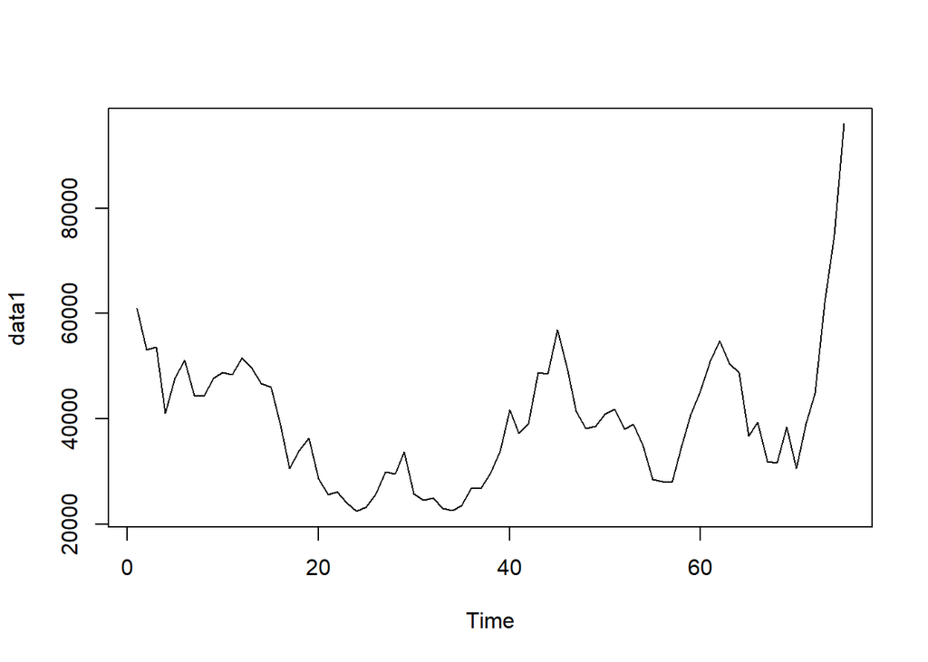

```r
plot.ts(data1)
```

2. plot ACF partisi 1

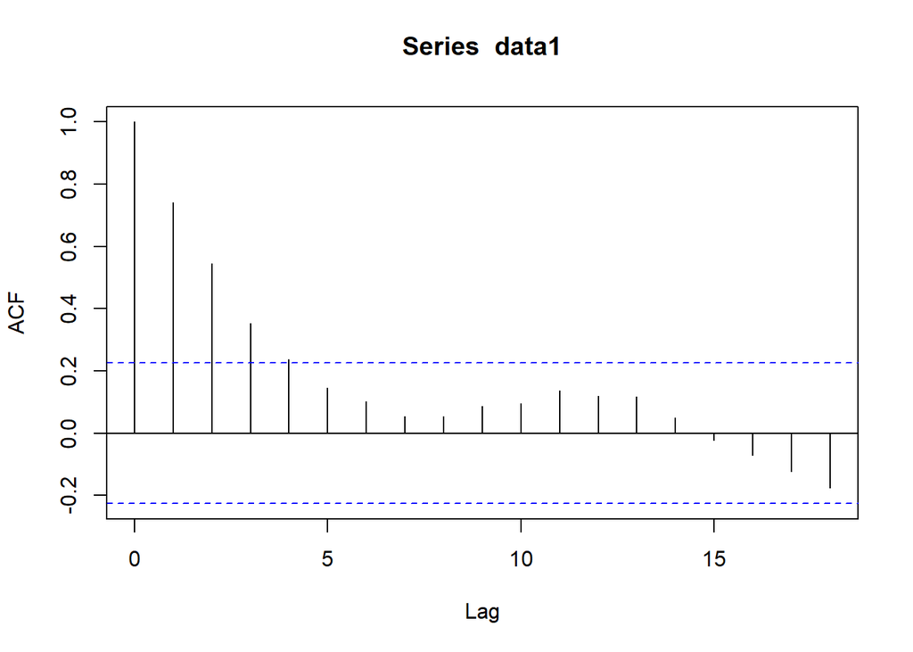

```r
acf(data1)
```

Berdasarkan plot ACF, terlihat bahwa plot ACF pada data tersebut menurun secara perlahan (*tails off slowly*) yang menandakan data tidak stasioner dalam rataan

3. uji ADF

```r
adf.test(data1)
```

```
##
##  Augmented Dickey-Fuller Test
##
## data:  data1
## Dickey-Fuller = -1.1976, Lag order = 4, p-value = 0.9011
## alternative hypothesis: stationary
```

$H_0$ : Data tidak stasioner dalam rataan

$H_1$ : Data stasioner dalam rataan diperoleh nilai p value > dari taraf 5% sehingga dapat disimpulkan bahwa data partisi 1 tidak stasioner dalam rataan sesuai dengan plot ACF

4. plot box cox

```r
index <- seq(1:75)
bc = boxcox(data1~index, lambda = seq(-2,2,by=0.1))
```

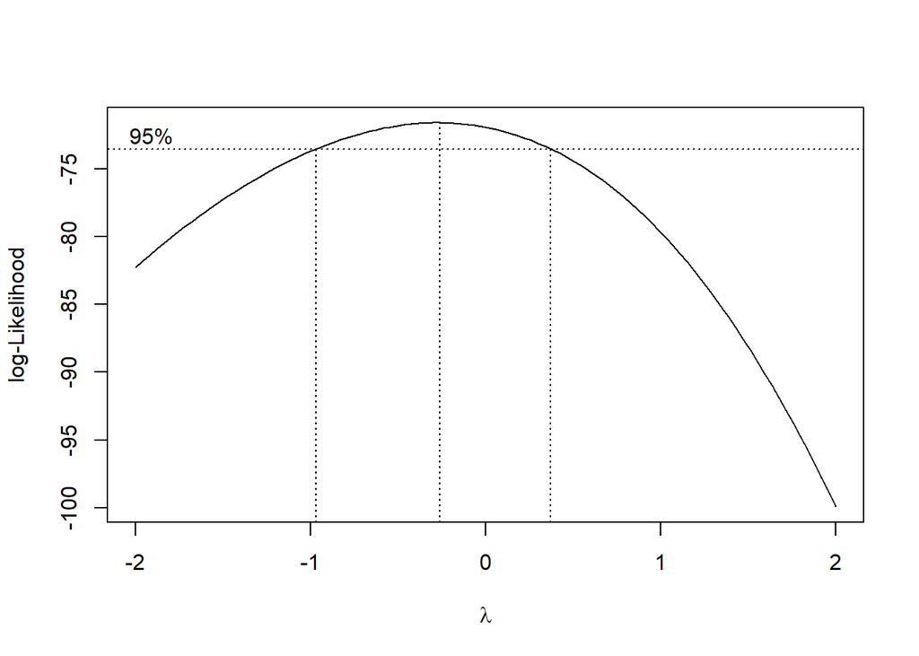

```r
#Nilai Rounded Lambda
lambda <- bc$x[which.max(bc$y)]
lambda
```

[output not shown]

```r
#SK
bc$x[bc$y > max(bc$y) - 1/2 * qchisq(.95,1)]
```

[output not shown]

Dari plot box cox dapat dilihat dalam selang kepercayaan 95% tidak mengandung lambda = 1, sehingga dapat disimpulkan bahwa data tidak stasioner dalam ragam

```r
data2 <- data[76:138] |> ts()
mean(data2)
```

```
## [1] 51321.43
```

```r
var(data2)
```

```
## [1] 481553203
```

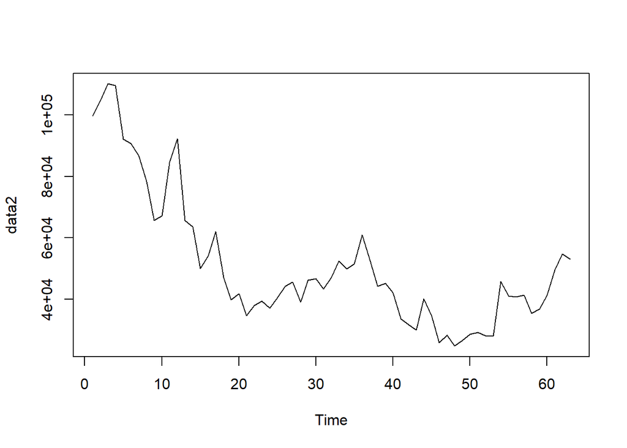

```r
plot.ts(data2)
```

2. plot ACF partisi 2

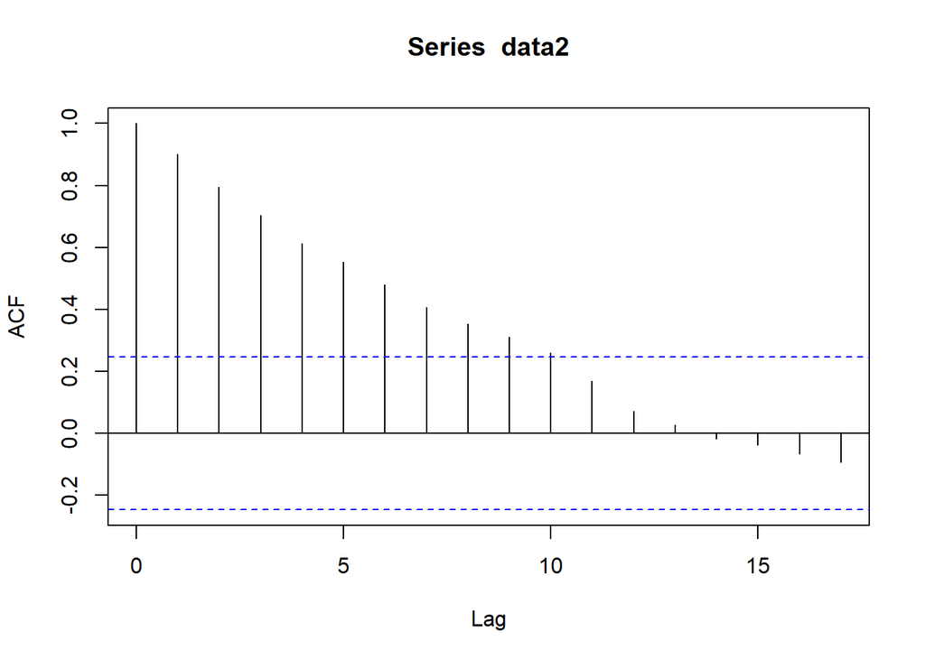

```r
acf(data2)
```

Berdasarkan plot ACF, terlihat bahwa plot ACF pada data tersebut menurun secara perlahan (*tails off slowly*) yang menandakan data tidak stasioner dalam rataan

3. uji ADF partisi 2

```r
adf.test(data2)
```

```
##
##  Augmented Dickey-Fuller Test
##
## data:  data2
## Dickey-Fuller = -2.0803, Lag order = 3, p-value = 0.5424
## alternative hypothesis: stationary
```

$H_0$ : Data tidak stasioner dalam rataan

4. plot box cox

```r
index <- seq(1:63)
bc = boxcox(data2~index, lambda = seq(-3,2,by=0.01))
```

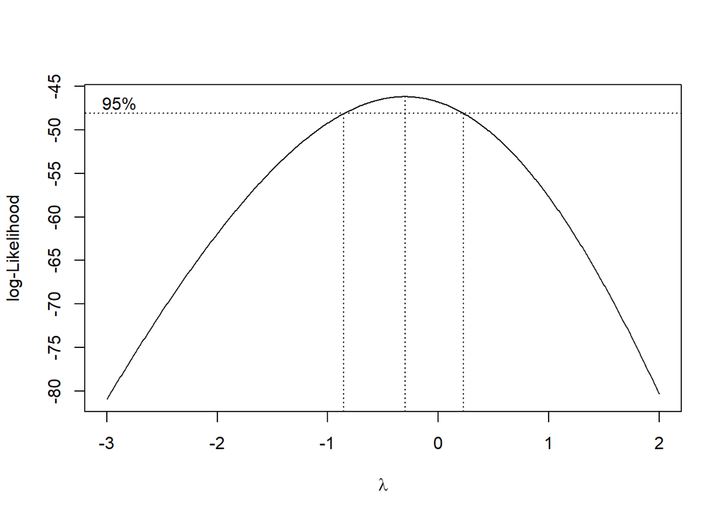

```r
#Nilai Rounded Lambda
lambda <- bc$x[which.max(bc$y)]
lambda
```

```
## [1] -0.3
```

```r
#SK
bc$x[bc$y > max(bc$y) - 1/2 * qchisq(.95,1)]
```

```
##   [1] -0.85 -0.84 -0.83 -0.82 -0.81 -0.80 -0.79 -0.78 -0.77 -0.76 -0.75 -0.74
##  [13] -0.73 -0.72 -0.71 -0.70 -0.69 -0.68 -0.67 -0.66 -0.65 -0.64 -0.63 -0.62
##  [25] -0.61 -0.60 -0.59 -0.58 -0.57 -0.56 -0.55 -0.54 -0.53 -0.52 -0.51 -0.50
##  [37] -0.49 -0.48 -0.47 -0.46 -0.45 -0.44 -0.43 -0.42 -0.41 -0.40 -0.39 -0.38
##  [49] -0.37 -0.36 -0.35 -0.34 -0.33 -0.32 -0.31 -0.30 -0.29 -0.28 -0.27 -0.26
##  [61] -0.25 -0.24 -0.23 -0.22 -0.21 -0.20 -0.19 -0.18 -0.17 -0.16 -0.15 -0.14
##  [73] -0.13 -0.12 -0.11 -0.10 -0.09 -0.08 -0.07 -0.06 -0.05 -0.04 -0.03 -0.02
##  [85] -0.01  0.00  0.01  0.02  0.03  0.04  0.05  0.06  0.07  0.08  0.09  0.10
##  [97]  0.11  0.12  0.13  0.14  0.15  0.16  0.17  0.18  0.19  0.20  0.21  0.22
## [109]  0.23
```

Dari plot box cox dapat dilihat dalam selang kepercayaan 95% tidak mengandung lambda = 1, sehingga dapat disimpulkan bahwa data tidak stasioner dalam ragam